# STA 141A Final Project

Samantha Isabel Zaraspe - SID: 918284646

2023-06-07

## Abstract

Within this project, we will be creating a predictive model that will allow us to forecast the outcome of different trials using different variables within a given dataset. In order to accomplish this, we will focus on a data subset collected by Steinmetz et al. in 2019. We will also create and use a Logistic Regression model to help us with these predictions.

## I. Introduction

Before we can begin to analyze this data, we must first understand how our data was acquired, as well as what each of part of the variable means. The original set of data consists of 39 sessions worth of hundreds of experimental trials that were performed on 10 different mice. These mice were randomly presented visual stimuli on two different sides on either side of the mouse. The visuals that were shown to each mouse varied randomly in contrast level. These contrast levels were numerically labeled as {0, 0.25, 5, 1}, where 0 means there was no stimulus on the screen at all. Depending on the difference in contrast between the two monitors, each mouse was expected to respond in certain ways by turning a wheel with its forearms. This particular dataset focuses on a few possible scenarios that may occur with the two monitors. If the two monitors had different visuals and the mouse turned the wheel in the direction of the stimulus with the brighter contrast, it was recorded a ‘success’ and assigned a value of (1). Otherwise, it was considered a failure and recorded as a (-1). Additionally, if both monitors had a contrast level of 0, a success response would be recorded if the mouse did not move the wheel. Finally, if both the monitors had equal, non-zero contrasts, the successful response was randomly selected. In addition to the feedback recorded within these trials, the neurological activity of each mouse’s visual courtex was recorded, as well as the timestamps that correspond to when neurons were triggered.

The subset utilized within this project consists of the data from 18 experiment sessions that were ran on 4 of those mice: Cori, Frossman, Hence, and Lederberg. Within this subset, we have a few variables that were recorded: each of the mice’s names represented by ‘mouse_name,’ the date the session was held labelled ‘date_exp’, the number of neurons or ‘n_neurons,’ the number of trials ‘n_trials,’ and finally the success rate fittingly referred to as ‘success rate.’

As we examine this dataset, we will attempt to find any patterns that may indicate a cause for a mouse’s success or failure in a given trial. There are a few potential causes that may contribute to the success rate of a session. In particular, the success rate of a mouse may be attributed to either the amount of neurons activated or the number of trials the mouse undergoes. Although some may theorize that brain activity has the largest influence on the success rate, it is also possible that a mouse’s ability to respond correctly is contingent on the amount of time it has had to build up a habit or to learn instead.

Keeping these possibilities in mind as we continue with this project, we will create a predictive model that will help us forecast what the success rate of a mouse will be based on its neural activity.

## II. Exploratory Analysis

In order to observe any significant influences on the success rate of these mice, we must visualize and compare data across the different trials and sessions within this subset.

| mouse_name | date_exp | n_brain_area | n_neurons | n_trials | success_rate |
| --- | --- | --- | --- | --- | --- |
| Cori | 2016-12-14 | 8 | 734 | 114 | 0.61 |
| Cori | 2016-12-17 | 5 | 1070 | 251 | 0.63 |
| Cori | 2016-12-18 | 11 | 619 | 228 | 0.66 |
| Forssmann | 2017-11-01 | 11 | 1769 | 249 | 0.67 |
| Forssmann | 2017-11-02 | 10 | 1077 | 254 | 0.66 |
| Forssmann | 2017-11-04 | 5 | 1169 | 290 | 0.74 |
| Forssmann | 2017-11-05 | 8 | 584 | 252 | 0.67 |
| Hench | 2017-06-15 | 15 | 1157 | 250 | 0.64 |
| Hench | 2017-06-16 | 12 | 788 | 372 | 0.69 |
| Hench | 2017-06-17 | 13 | 1172 | 447 | 0.62 |
| Hench | 2017-06-18 | 6 | 857 | 342 | 0.80 |
| Lederberg | 2017-12-05 | 12 | 698 | 340 | 0.74 |
| Lederberg | 2017-12-06 | 15 | 983 | 300 | 0.80 |
| Lederberg | 2017-12-07 | 10 | 756 | 268 | 0.69 |
| Lederberg | 2017-12-08 | 8 | 743 | 404 | 0.76 |
| Lederberg | 2017-12-09 | 6 | 474 | 280 | 0.72 |
| Lederberg | 2017-12-10 | 6 | 565 | 224 | 0.83 |
| Lederberg | 2017-12-11 | 10 | 1090 | 216 | 0.81 |

```
##       ACA       CA1        DG       LGd        LH        MD       MOs        PL
## 0.8125000 2.1800000 1.1384615 2.7272727 5.1111111 1.4841270 0.0000000 0.4821429
##      root       SUB     VISam      VISp
## 1.0400000 0.9904762 1.3291139 0.3181818
```

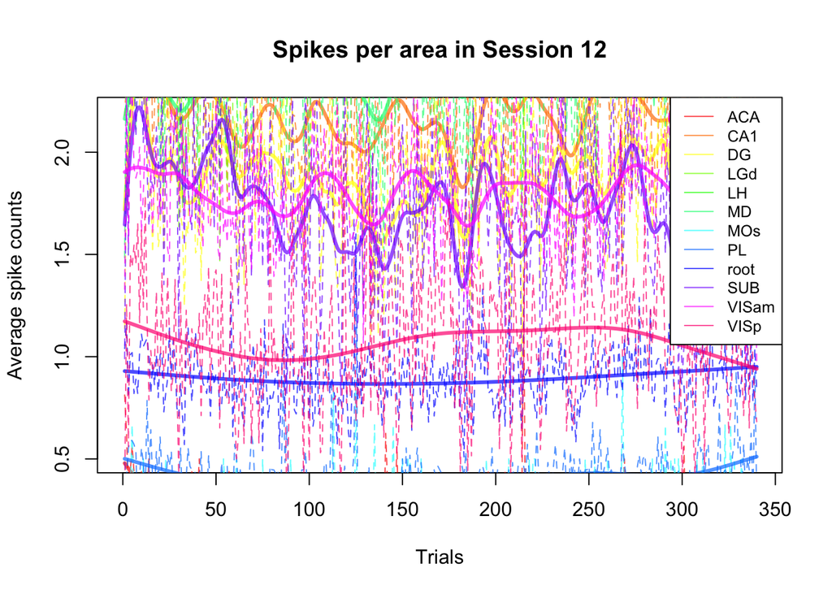

Depicted above is a line graph of the average spike count across all the trials within Session 12. Due to the larger number of brain areas that were active during the trials, the graph above appears to be quite hectic, despite a lower number of neurons being fired. It appears that the areas SUB, VISam, CA1, DG, and MD had the most neurons fire, as the line depicting their averages appears to fluctuate, whereas the other areas have a more consistent average.

As we know from the table shown previously, this trial ended with a success rate of 0.74, one of the more average success rates within our sessions. It is possible that this larger scale of brain activity increased the chances for the mouse’s success, but it is not definitive enough evidence for us to conclude that neural activity is the sole cause of raise in these rates. Time spent experiencing these experiments may still be a major factor in improving results. Let us explore this idea more by comparing this line graph of Session 12’s trial data to that of Session 18, the last session Lederberg underwent.

```
##       ACB       CA3        CP       LGd        OT      root        SI       SNr
## 1.2709677 1.6285714 1.1329114 0.7865169 0.8461538 2.0808081 1.8541667 0.8000000
##        TH        ZI
## 1.0571429 1.1257143
```

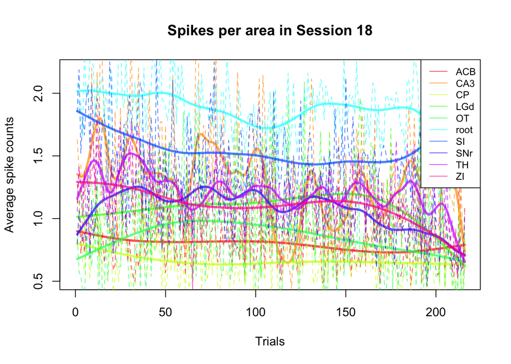

With a more focused idea of what to look for within our data, let us look at a comparison between the first and last trial of Session 18 in order to observe whether any of our proposed reasons have more prevalence.

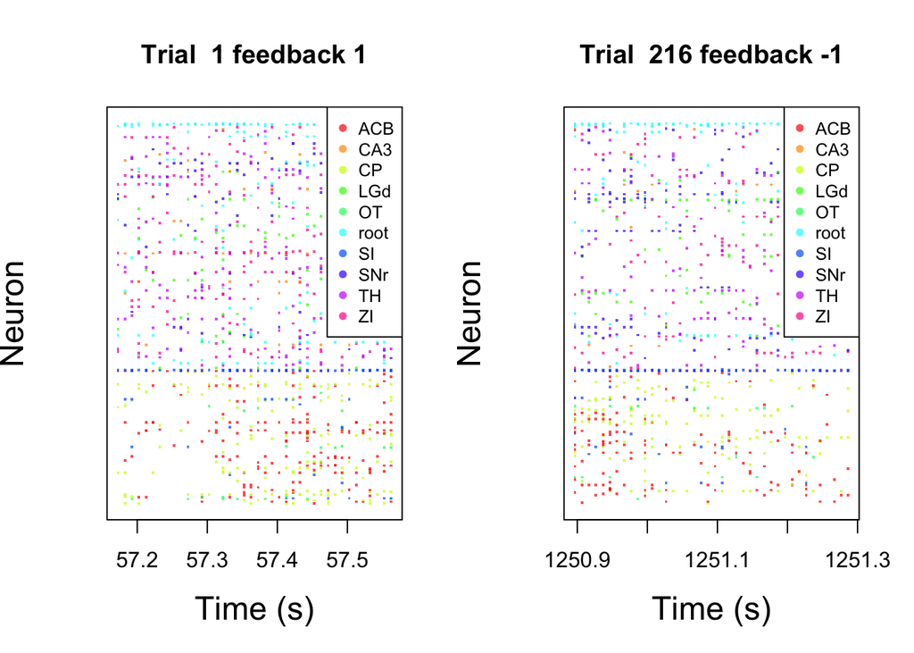

Illustrated above are plots of the neurons that were fired over time within the first and final trials of Session 18, Lederberg’s final session. When observing the plots above, we can see that one constant kind of neurons that had been firing between the two sessions are root and SI. This is shown on the graph as an almost dotted, horizontal line across the graph, meaning that most of the data points associated with these neurons fire consistently. This may indicate that these neurons are vital for a mouse to process the trials it is undergoing. Additionally, ZI has a horizontal pattern across the first trial’s graph, but dissipates by the 216th trial. The absence of this neuron firing may be a cause of the 216th trial failing, while the first trial succeeded.

After observing the previous comparisons, there is a possibility that the quantity of neural activity within the brain of a mouse may have a significant effect on the success rate of a mouse’s sessions. Because of this, we may move to explore utilizing the data we have on neurological activity to predict whether a mouse is to succeed or not.

## III. Data Integration

```
##     session mouse_name   date_exp feedback_type contrast_left contrast_right
## 1 Session 1       Cori 2016-12-14             1           0.0            0.5
## 2 Session 1       Cori 2016-12-14             1           0.0            0.0
## 3 Session 1       Cori 2016-12-14            -1           0.5            1.0
## 4 Session 1       Cori 2016-12-14            -1           0.0            0.0
## 5 Session 1       Cori 2016-12-14            -1           0.0            0.0
## 6 Session 1       Cori 2016-12-14             1           0.0            0.0
##   average_spike_trial
## 1            1.581744
## 2            1.311989
## 3            1.844687
## 4            1.381471
## 5            1.425068
## 6            1.094005
```

Shown above are the first six rows of a new integrated dataset. This dataset contains all the trial data across all sessions, as well as a new additional column containing the average number of spikes within each trial. We will be using this to create a benchmark for our predictive model, before moving on to testing it.

## IV. Predictive Modeling

We will be utilizing a Logistic Regression Model to create our predictive model.

```
##
##      FALSE TRUE
##   -1    32  263
##   1     24  698
```

```
## [1] 0.7263267
```

```
## [1] 0.966759
```

```
## [1] 0.8294712
```

```
## [1] 0.2822026
```

Shown above is the confusion matrix for our model, as well as our precision rate, recall rate, f1 value, and misclassification error rate. Respectively, these values rounded to the second decimal place are 0.73, 0.97, 0.83, and 0.28.

## V. Prediction Performance on the Test Sets and Discussion

In order to test the efficacy of our predictive model, we must run a prediction performance test.

| mouse_name | date_exp | n_brain_area | n_neurons | n_trials | success_rate |
| --- | --- | --- | --- | --- | --- |
| Cori | 2016-12-14 | 8 | 734 | 100 | 0.72 |
| Lederberg | 2017-12-11 | 10 | 1090 | 100 | 0.73 |

```
##     session mouse_name   date_exp feedback_type contrast_left contrast_right
## 1 Session 1       Cori 2016-12-14            -1          0.25           0.25
## 2 Session 1       Cori 2016-12-14             1          0.00           0.00
## 3 Session 1       Cori 2016-12-14             1          1.00           0.50
## 4 Session 1       Cori 2016-12-14             1          0.00           0.50
## 5 Session 1       Cori 2016-12-14             1          1.00           0.50
## 6 Session 1       Cori 2016-12-14             1          0.50           0.25
##   average_spike_trial
## 1            1.433243
## 2            1.555858
## 3            1.884196
## 4            1.831063
## 5            1.587193
## 6            1.369210
```

Depicted above is the first 6 rows of our first set of testing data, with the inclusion of the average number of spikes within the trial.

```
##
##      FALSE TRUE
##   -1     1    2
##   1      7   13
```

```
## [1] 0.8666667
```

```
## [1] 0.65
```

```
## [1] 0.7428571
```

The confusion matrix for the model is shown above. Additionally, the precision rate, recall rate, and f1 values are 0.86, 0.65, and 0.74 respectively. Compared to our benchmark, our precision rate has increased.

# Reference

Referred to a few of the discussion posts to assist with code, in particular Discussion8 and Discussion10. Additionally, I looked to Piazza for a lot of guidance, as well as troubleshooted my code with fellow student, Jason Javier.

Steinmetz, N.A., Zatka-Haas, P., Carandini, M. et al. Distributed coding of choice, action and engagement across the mouse brain. Nature 576, 266–273 (2019). https://doi.org/10.1038/s41586-019-1787-x

# Appendix

```
knitr::opts_chunk$set(echo = TRUE)
setwd("/Users/samisubi/Desktop/STA 141A Work/Final Project")
library(tidyverse)
library(magrittr)
library(knitr)
library(dplyr)
library(caTools)
setwd("/Users/samisubi/Desktop/STA 141A Work/Final Project/sessions")
session = list()
for(i in 1:18){
  session[[i]]=readRDS(paste('session',i,'.rds',sep=''))
}
n.session=length(session)

meta <- tibble(
  mouse_name = rep('name',n.session),
  date_exp =rep('dt',n.session),
  n_brain_area = rep(0,n.session),
  n_neurons = rep(0,n.session),
  n_trials = rep(0,n.session),
  success_rate = rep(0,n.session)
)

for(i in 1:n.session){
  tmp = session[[i]];
  meta[i,1]=tmp$mouse_name;
  meta[i,2]=tmp$date_exp;
  meta[i,3]=length(unique(tmp$brain_area));
  meta[i,4]=dim(tmp$spks[[1]])[1];
  meta[i,5]=length(tmp$feedback_type);
  meta[i,6]=mean(tmp$feedback_type+1)/2;
}
kable(meta, format = "html", table.attr = "class='table table-striped'",digits=2)
setwd("/Users/samisubi/Desktop/STA 141A Work/Final Project/sessions")
i.s = 12
i.t = 1

average_spike_area<-function(i.t,this_session){
  spk.trial = this_session$spks[[i.t]]
  area= this_session$brain_area
```

[output cut: 229 more lines]

```
                 family = binomial,
                 data = training_set_1)

probPred = predict(classifier, type = 'response', newdata = test_set_t1)
y_pred = ifelse(probPred > 0.5, 1, -1)

cm = table(test_set_t1[, 4], y_pred > 0.5)
print(cm)
precision <- sum(y_pred == 1 & test_set_t1[, 4] == 1) / sum(y_pred == 1)
precision
recall <- sum(y_pred == 1 & test_set_t1[, 4] == 1) / sum(test_set_t1[, 4] == 1)
recall
f1 <- 2 * precision *recall / (precision + recall)
f1
sessionInfo()
```